# Load Data

```python
import pandas as pd

df_posts = pd.read_csv('https://storage.googleapis.com/datalynn-datasets/interview-challenge/technology/Meta_News_Feed/df_posts.csv')
df_user_info = pd.read_csv('https://storage.googleapis.com/datalynn-datasets/interview-challenge/technology/Meta_News_Feed/df_user_info.csv')
df_user_feed = pd.read_csv('https://storage.googleapis.com/datalynn-datasets/interview-challenge/technology/Meta_News_Feed/df_user_feed.csv')

# convert time features
df_posts['post_timestamp'] = pd.to_datetime(df_posts['post_timestamp'])
df_user_info['last_active'] = pd.to_datetime(df_user_info['last_active'])
df_user_feed['timestamp'] = pd.to_datetime(df_user_feed['timestamp'])
```

# Solution

## Question 1

**Scenario:** We've noticed a surge in the interaction with posts that are videos.

Determine which age group and country combo has the highest interaction rate with video content in the past month. This will help us understand our demographic better. How would you approach this?

**Hints:**

1. **Filter the Data**: First, we'll focus only on video content and interactions within the past month.
2. **Join Tables**: We'll join the necessary tables (in this case, `df_user_feed`, `df_posts`, and `df_user_info`) to get the `age_group` and `country` for each interaction with video content.
3. **Calculate Interaction Rate**: For each age group and country combo, we'll calculate the interaction rate by dividing the number of interactions with video content by the total number of posts viewed by that demographic.
4. **Visualize or Display**: Finally, we'll either visualize or display the results to identify the age group-country combo with the highest interaction rate.

```python
import pandas as pd
import sqlite3

# Create a SQLite database connection
conn = sqlite3.connect(":memory:")

# Load dataframes into SQL tables
df_posts.to_sql("posts", conn, index=False)
df_user_info.to_sql("user_info", conn, index=False)
df_user_feed.to_sql("user_feed", conn, index=False)

# Extract interactions from the past month for video content
sql = """
SELECT user_info.age_group, user_info.country, COUNT(*) as video_interactions
FROM user_feed
JOIN posts ON user_feed.post_id = posts.post_id
JOIN user_info ON user_feed.user_id = user_info.user_id
WHERE posts.content_type = 'video'
AND julianday('now') - julianday(user_feed.timestamp) <= 30
GROUP BY user_info.age_group, user_info.country
ORDER BY video_interactions DESC
LIMIT 1;
"""

result = pd.read_sql(sql, conn)
print(result)

# Close the SQLite connection
conn.close()
```

```
  age_group country  video_interactions
0     35-44   India                   4
```

## Question 2

Given that the News Feed algorithm's goal is to prioritize the most relevant content, consider the following: If we have information that a certain user (please use 'user_100' in this question) frequently interacts with posts from a particular creator and this creator has posted new content within "2023-08-17" and "2023-08-18", how would you design a SQL query to fetch such posts? Also, ensure that sponsored posts get a slightly higher priority.

**Hints:**

1. **Identify Frequent Interactions**: We'll need to first identify creators with whom a user frequently interacts.
2. **Filter Recent Posts**: Then, from those creators, we'll fetch posts that have been made within the last 24 hours.
3. **Prioritize Sponsored Posts**: We'll make sure that if these creators have both sponsored and non-sponsored posts, the sponsored posts are prioritized.

**SQL Query Hints:**

1. **Sub-query for Frequent Interactions**: We'll create a sub-query to get the creators that a user frequently interacts with. This could be based on a threshold (e.g., more than 5 interactions in the last month).
2. **Join with Posts**: Join this sub-query result with the `posts` table to fetch the recent posts from these creators.
3. **Ordering**: The result will be ordered first by the `is_sponsored` column in descending order (to give priority to sponsored posts) and then by the `post_timestamp` in descending order (to get the most recent posts first).

```python
import pandas as pd
import sqlite3

# Assuming the dataframes are already loaded

# Create a SQLite database connection
conn = sqlite3.connect(":memory:")

# Load dataframes into SQL tables
df_posts.to_sql("posts", conn, index=False)
df_user_info.to_sql("user_info", conn, index=False)
df_user_feed.to_sql("user_feed", conn, index=False)

# Define user_id for which we want to fetch posts
user_id = 'user_100'  # Replace with the actual user_id

sql = """
WITH FrequentCreators AS (
    SELECT creator_id
    FROM user_feed
    JOIN posts ON user_feed.post_id = posts.post_id
    WHERE user_feed.user_id = ?
    GROUP BY posts.creator_id
    HAVING COUNT(user_feed.post_id) > 2  -- This threshold can be adjusted
)

SELECT posts.*
FROM posts
JOIN FrequentCreators ON posts.creator_id = FrequentCreators.creator_id
WHERE posts.post_timestamp BETWEEN '2023-08-17' AND '2023-08-18'
ORDER BY posts.is_sponsored DESC, posts.post_timestamp DESC;
"""

result = pd.read_sql(sql, conn, params=(user_id,))
print(result)

# Close the SQLite connection
conn.close()
```

```
   post_id content_type   creator_id       post_timestamp  is_sponsored
0  post_92        image  creator_128  2023-08-17 20:17:00             1
1  post_70        image  creator_128  2023-08-17 10:20:00             1
2  post_48        video  creator_128  2023-08-17 07:57:00             1
```

## Question 3

**Scenario:** A recent A/B test suggested that users who engage with text-based posts spend more time on the platform than others.

Based on this, compute the average time difference between a user's last interaction with a text post and their last active timestamp. Would this information be a compelling case for the algorithm to prioritize text posts for these users? Justify.

**Hints & Explanations**

1. **Data Preparation**:
   - Join the relevant data tables.
   - Filter the interactions related to text posts.
   - Calculate the time difference between a user's last interaction with a text post and their last active timestamp.
2. **Analysis**:
   - Compute the average time difference for all users.
   - Visualize the distribution of time differences to observe the patterns.
3. **Comment and Justify**:
   - Analyze the computed and visualized data to make conclusions.

**1. Data Preparation**

**Joining the relevant data tables**

First, we need to combine our datasets to get the necessary information. Specifically, we want the `interaction`, `timestamp` from the `df_user_feed`, the `content_type` from `df_posts`, and the `last_active` timestamp from `df_user_info`.

```python
# Join the df_user_feed with df_posts on post_id
df_combined = df_user_feed.merge(df_posts, on='post_id', how='inner')

# Join the combined df with df_user_info on user_id
df_combined = df_combined.merge(df_user_info, on='user_id', how='inner')
```

**Filter interactions related to text posts and Calculate the time difference**

We'll filter out the rows where the content type is text and then compute the time difference.

```python
# Filter rows where content_type is text
text_interactions = df_combined[df_combined['content_type'] == 'text'].copy()

# Calculate the time difference
text_interactions['time_diff'] = (text_interactions['last_active'] - text_interactions['timestamp']).dt.total_seconds() / 3600  # This will give time difference in hours
```

**2. Analysis**

**Compute the average time difference for all users**

```python
# 2. Analysis
# Compute the average time difference for all users
avg_time_diff = text_interactions.groupby('user_id')['time_diff'].mean()
print(f"The average time difference between users' last interaction with a text post and their last active timestamp is: {avg_time_diff.mean()} hours")
```

```
The average time difference between users' last interaction with a text post and their last active timestamp is: 4596.7135986733 hours
```

[figure not shown]

```python
# Visualize the distribution
import matplotlib.pyplot as plt

avg_time_diff.hist(bins=30, edgecolor='k', alpha=0.7)
plt.title('Distribution of Average Time Differences')
plt.xlabel('Time Difference (minutes)')
plt.ylabel('Number of Users')
plt.show()
```

Let's modify the comments:

**Justification**: This prolonged interaction with text posts suggests a few key insights:

1. **Longevity of Content**: Text-based posts seem to have a 'longer shelf-life'. Their content remains relevant and attractive to users even after a considerable amount of time. This is unlike other forms of content which might become outdated or lose their appeal faster.
2. **User Behavior**: Users might be revisiting older posts for reference, discussions, or because the content is evergreen. It's also possible that new users are discovering older content and finding value in it.
3. **Search and Discovery**: The platform's search and recommendation algorithms might be effectively bringing up older, relevant text content for users.

Given this data, there's a compelling argument to continue giving weight to text-based content in the recommendation system. By doing so, Facebook can leverage the longevity and sustained relevance of text content to keep users engaged. However, it's also essential to balance with fresher content to keep the News Feed dynamic and up-to-date.

## Question 4

One of the complexities in curating the News Feed is managing sponsored content. How would you approach the balance between showing users sponsored content while maintaining a high level of user engagement? Taking into consideration the provided data, construct a model to predict the likelihood of a user interacting with a sponsored post. What features would be significant for this model?

**Hints:**

1. **Data Understanding and Exploration**
   - Understand the distribution of sponsored and non-sponsored content.
   - Explore how often users interact with sponsored vs. non-sponsored content.
2. **Feature Engineering**
   - Derive new features that might be useful for the prediction model.
3. **Model Building**
   - Split data into training and testing sets.
   - Choose an appropriate algorithm for the model.
   - Train the model and validate it.

**1. Data Understanding and Exploration**

To start with, let's explore how often users interact with sponsored vs. non-sponsored content.

```
interaction   comment  like  share
is_sponsored
0                  68   482    141
1                  22   227     60
```

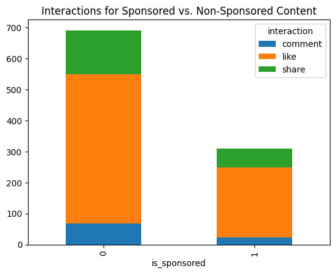

```python
# 1. Data Understanding and Exploration
import pandas as pd
import matplotlib.pyplot as plt

# Merging tables
merged_df = pd.merge(df_user_feed, df_posts, on="post_id", how="left")

# Count interactions for sponsored vs. non-sponsored content
interaction_counts = merged_df.groupby("is_sponsored")["interaction"].value_counts().unstack().fillna(0)

print(interaction_counts)

interaction_counts.plot(kind="bar", stacked=True)
plt.title("Interactions for Sponsored vs. Non-Sponsored Content")
plt.show()
```

**Comment:**

From the plot, we could get an understanding of how user interactions differ for sponsored and non-sponsored content. For instance, if "likes" are much higher for non-sponsored content, it might indicate users prefer organic content.

**2. Feature Engineering & Modeling**

Using the provided features:

- `content_type`: Type of the content might play a role in interaction.
- `time_since_post_creation`: Time since the post was created.
- `creator_id`: Some creators might generate more engaging sponsored content.

```python
# 2. Feature Engineering & Modeling
from sklearn.model_selection import train_test_split
from sklearn.linear_model import LogisticRegression
from sklearn.metrics import classification_report

import warnings
warnings.simplefilter(action='ignore', category=Warning)


merged_df["time_since_post_creation"] = (merged_df["timestamp"] - merged_df["post_timestamp"]).dt.total_seconds() / 3600  # in hours

# One-hot encoding categorical variables
encoded_df = pd.get_dummies(merged_df[["content_type", "creator_id", "time_since_post_creation"]], drop_first=True)

X = encoded_df
y = merged_df["interaction"]

X_train, X_test, y_train, y_test = train_test_split(X, y, test_size=0.2, random_state=42)

model = LogisticRegression(max_iter=1000)  # Increasing max_iter for convergence
model.fit(X_train, y_train)

y_pred = model.predict(X_test)
print(classification_report(y_test, y_pred))
```

```
              precision    recall  f1-score   support

     comment       0.00      0.00      0.00        20
        like       0.71      0.99      0.82       141
       share       0.00      0.00      0.00        39

    accuracy                           0.69       200
   macro avg       0.24      0.33      0.27       200
weighted avg       0.50      0.69      0.58       200
```

**Conclusion**

However, the dataset lacks user-specific features, which might be essential for a more precise model. It would be beneficial to consider user preferences, historical interactions, etc., for a more comprehensive recommendation system in the future.